# STAT5003 Week 6 Homework

- Show All Code
- Hide All Code
- View Source

Semester 1B, 2023

```r
library(tidyverse)
library(mice)
```

This week, a simple dataset will be explored with and without missing data and its effect on modelling. To begin download the `skin-cancer.csv` file.

# 1 Simple regression with and without missingness

Consider this older data set that shows the mortality rates (number of deaths per 10 million people) skin cancer for some US states against the latitude of the state. The data is available in `skin-cancer.csv` on Canvas.

```r
set.seed(5003)
full.data <- read.csv("skin-cancer.csv", header = TRUE)
```

## Standard Simple regression without missingness

Conduct a simple linear regression with the Mortality rates as the response and Latitude as the predictor. Plot the data along with the regression and interpret the regression output.

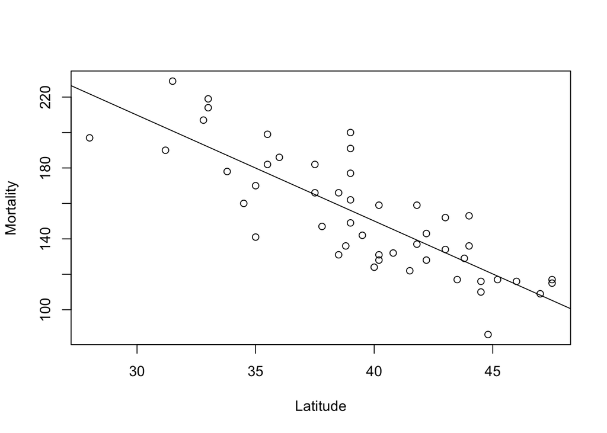

```r
full_model <- lm(Mort ~ Lat, data = full.data)
plot(Mort ~ Lat, data =full.data, ylab = "Mortality", xlab = "Latitude")
abline(full_model)
```

```r
summary(full_model)
```

```
Call:
lm(formula = Mort ~ Lat, data = full.data)

Residuals:
    Min      1Q  Median      3Q     Max
-38.972 -13.185   0.972  12.006  43.938

Coefficients:
            Estimate Std. Error t value Pr(>|t|)
(Intercept) 389.1894    23.8123   16.34  < 2e-16 ***
Lat          -5.9776     0.5984   -9.99 3.31e-13 ***
---
Signif. codes:  0 '***' 0.001 '**' 0.01 '*' 0.05 '.' 0.1 ' ' 1

Residual standard error: 19.12 on 47 degrees of freedom
Multiple R-squared:  0.6798,    Adjusted R-squared:  0.673
F-statistic:  99.8 on 1 and 47 DF,  p-value: 3.309e-13
```

Fitted model is $\widehat{Mort} = 389 - 5.9776 \cdot Lat$

Regression output interpretation: - The intercept represents the estimated mortality rate when the latitude is zero - The estimated coefficient for Lat indicates that for every one unit increase in latitude, the mortality rate decreases by approximately 5.9776. - The p-value for the coefficient of Lat is very small, indicating strong evidence against the null hypothesis that there is no relationship between latitude and mortality rates. The coefficient is statistically significant. - The R-squared value is 0.6798 which indicates that approximately 67.98% of the variability in mortality rates can be explained by the linear relationship with latitude. - From the plot we can see there is a significant negative relationship between latitude and mortality rates for skin cancer. As latitude increases, the mortality rates tend to decrease. However, it is important to note that this is a simple analysis and other factors may also contribute to the observed mortality rates.

## Simulate missingness in the latitudes

Simulate half the values in the Latitude feature to be missing at random values. (i.e. replace half the elements with missing `NA` values). Note the assignment of missing values to be is random but not completely at random. That is, the chance that Latitude is missing should depend on Mortality. A good convenient function for this purpose is available in `mice::ampute`. The return object of this function will contain the data with missingness in the element `amp`. E.g. if you assigned the output of the `mice::ampute` to an object called `output`, the data with missing values will be available in `output$amp`. We’ll call this the amputed data.

```r
set.seed(5003)
amputed_data <- ampute(full.data, prop = 0.5, patterns = data.frame(Lat = 1, Mort = 0))
# Take the counts and map to the proportion (average)
colMeans(is.na(amputed_data$amp))
```

```
     Mort       Lat
0.0000000 0.5306122
```

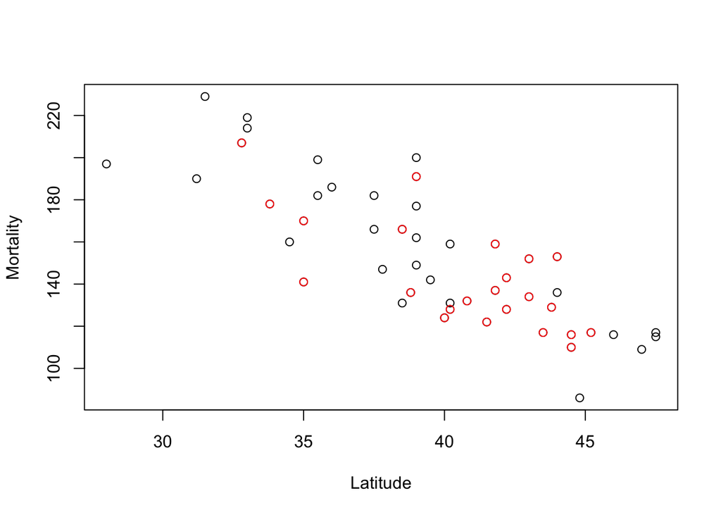

```r
# Let's plot the data and visualize which data points were amputed.
plot(Mort ~ Lat, data = full.data, ylab = "Mortality", xlab = "Latitude")
# Method 1 :
amp <- amputed_data[["amp"]]
with(amp, points(Lat, Mort, col = "red"))
```

## Original with missingness complete-case regression

Conduct a complete-case regression on the amputed data with Mortality as the response and Latitude as the predictor and show that it is not consistent with the original regression using the full data.

```r
complete_model_on_amp <- lm(Mort ~ Lat, data = amp)
summary(complete_model_on_amp)
```

```
Call:
lm(formula = Mort ~ Lat, data = amp)

Residuals:
    Min      1Q  Median      3Q     Max
-30.923 -12.402  -1.923   9.934  39.530

Coefficients:
            Estimate Std. Error t value Pr(>|t|)
(Intercept)  350.893     43.794   8.012 8.03e-08 ***
Lat           -5.113      1.073  -4.764 0.000105 ***
---
Signif. codes:  0 '***' 0.001 '**' 0.01 '*' 0.05 '.' 0.1 ' ' 1

Residual standard error: 18.05 on 21 degrees of freedom
  (26 observations deleted due to missingness)
Multiple R-squared:  0.5194,    Adjusted R-squared:  0.4965
F-statistic: 22.69 on 1 and 21 DF,  p-value: 0.0001049
```

```r
# Plot the original (full data) and the regression line using the original data.
# On the same plot show the amputed data and the regression line using only the amputed data
```

[output not shown]

## Simple regression on the missing data as the response

Conduct a simple linear regression now on the *amputed* data but instead regressing Latitude on Mortality. That is, do a regression where Latitude is the response and Mortality is the predictor but using the amputed data where some Latitude cases are missing. (Note that `R` will automatically remove missing values from the model when using `lm`)

Use this regression to predict the missing Latitudes and fill in the missing values in the amputed data. Call this new data.frame the basic imputed data.

```r
# Can fit another lm, with Latitude as the response and Mortality as the predictor
# on the amputed data
# fill in (impute) the missing values
missing_lat_model <- lm(Lat ~ Mort, data = amp)
# Use predict.lm to predict the missing Latitudes
missing_latitudes <- is.na(amp[["Lat"]])
newdat <- amp[missing_latitudes, ]
predicted_latitudes <- predict(missing_lat_model, newdata = newdat)
basic_imputed_dat <- amp
basic_imputed_dat[missing_latitudes, 2] <- predicted_latitudes
```